# STAT 400 Notes Lecture 3

Regression Review Part 3

Jan, 2025

## Front Matter - Clean Environment, Load Libraries, User Defined Functions

Remember to install package first: install.packages(“tidyverse”) install.packages(“lubridate”) install.packages(“ggplot2”)

```r
rm(list = ls()) #CAUTION: command erases everything in environment

#Put all library commands here
library(tidyverse)
#Read in all files here
derby <- read.csv(file = "https://raw.githubusercontent.com/proback/BeyondMLR/master/data/derbyplus.csv")
```

## Code from Lecture 2

```r
#Create New Variables
derby <- derby %>%
            mutate(fast = ifelse(condition == "fast", 1, 0),
                   good = ifelse(condition == "good", 1, 0),
                   fastfactor = ifelse(condition == "fast", "fast", "not fast"),
                   yearnew = year - 1896)
```

## Example 1a - How are the winning speeds distributed?

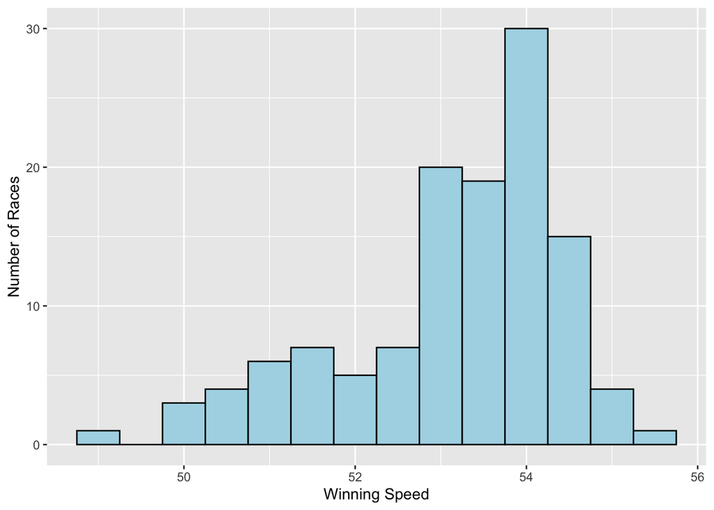

```r
ggplot(data = derby,
       mapping = aes(x = speed)) +
  geom_histogram(color = "black", fill = "lightblue", binwidth = 0.5) +
  labs(x = "Winning Speed",
       y = "Number of Races")
```

The distribution of winning speeds appears to be left skewed. The majority of winning speeds are between 51 and 55 ft/s.

The mean winning speed is 53.1690164. The standard deviation of winning speeds is 1.2894328.

## Example 1b - Are the winning speeds affected by the track condition?

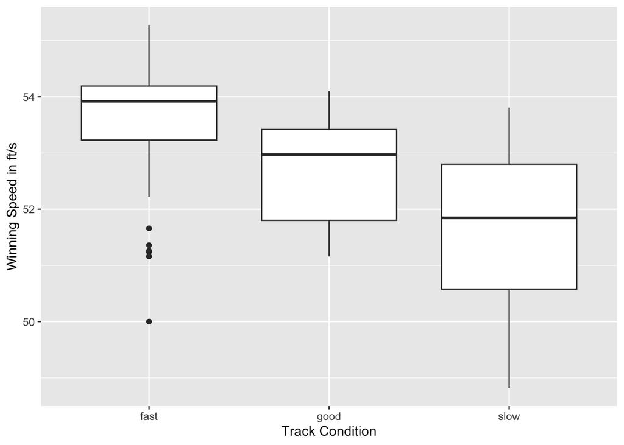

```r
ggplot(data = derby, mapping = aes(x = condition, y = speed)) +
  geom_boxplot() +
  labs(x = "Track Condition",
       y = "Winning Speed in ft/s")
```

```r
#Calculate summary statistics for each track condition
derby %>%
  group_by(condition) %>%
  summarize(N = n(),
            MeanSpeed = mean(speed, na.rm = TRUE),
            MedSpeed = median(speed, na.rm = TRUE),
            sdSpeed = sd(speed, na.rm = TRUE))
```

```
## # A tibble: 3 × 5
##   condition     N MeanSpeed MedSpeed sdSpeed
##   <chr>     <int>     <dbl>    <dbl>   <dbl>
## 1 fast         88      53.6     53.9   0.939
## 2 good         10      52.7     53.0   1.02
## 3 slow         24      51.7     51.8   1.36
```

## Example 1c - What is the relationship between winning speed, year, and whether track conditions were fast?

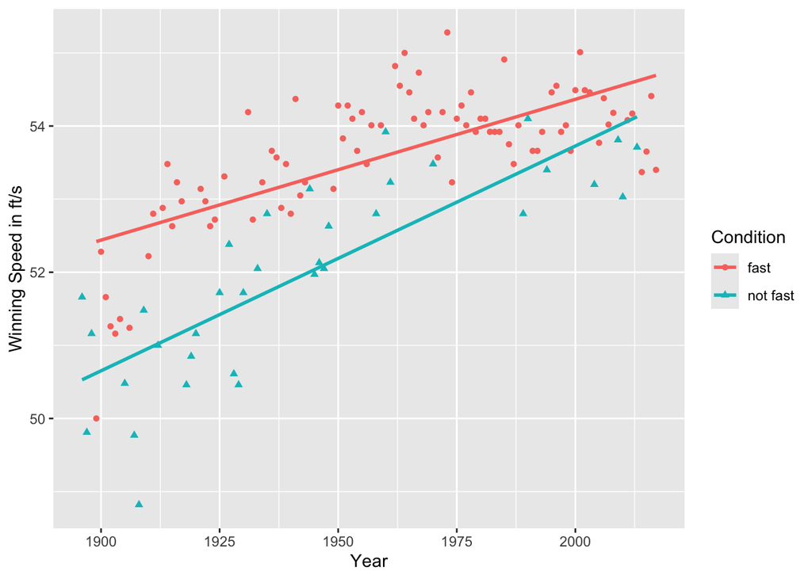

```r
#Create coded scatterplot
ggplot(data = derby,
       mapping = aes(x = year, y = speed,
                     color = fastfactor,
                     shape = fastfactor)) +
  geom_point() +
  geom_smooth(method = lm, se = FALSE) +
  labs(x = "Year",
       y = "Winning Speed in ft/s",
       color = "Condition",
       shape = "Condition")
```

```r
ggplot(data = derby,
       mapping = aes(x = year, y = speed,
                     color = as.factor(fast),
                     shape = as.factor(fast))) +
  geom_point() +
  geom_smooth(method = lm, se = FALSE) +
  labs(x = "Year",
       y = "Winning Speed in ft/s",
       color = "Condition",
       shape = "Condition")
```

[output not shown]

Informal Observations:

- red line is above blue. both slopes are positive. blue line has a steeper slope

Formal Observations:

- We expect faster winning times for fast track conditions.
- Under all track conditions, the the winning speeds are increasing over time.
- The rate of change of the speed with respect to the year (i.e., slope) is higher for good/slow conditions than fast conditions.
- Since the lines are different this would suggest that track conditions should be incorporated into the model for speed.

## Example 2a - Have winning speeds increased at a constant rate since 1896?

Write the true/population model. Define your notation.

The model is given by:

$$y_{i} = \beta_{0} + \beta_{1} x_{i,year}
+ \epsilon_{i}$$

where

$$\begin{aligned}
y_{i} &= \text{the winning speed in ft/s for the } i^{th}
\text{year} \\
x_{i,year} &= \text{year of the } i^{th} \text{race}
\end{aligned}$$

## Example 2b - Build Linear Regression Model

```r
#Build model
model1 <- lm(speed ~ year, data=derby)

#Summarize results
summary(model1)
```

```
##
## Call:
## lm(formula = speed ~ year, data = derby)
##
## Residuals:
##      Min       1Q   Median       3Q      Max
## -3.08190 -0.50026  0.07387  0.67367  1.68720
##
## Coefficients:
##             Estimate Std. Error t value Pr(>|t|)
## (Intercept) 2.053473   4.543754   0.452    0.652
## year        0.026126   0.002322  11.251   <2e-16 ***
## ---
## Signif. codes:  0 '***' 0.001 '**' 0.01 '*' 0.05 '.' 0.1 ' ' 1
##
## Residual standard error: 0.9032 on 120 degrees of freedom
## Multiple R-squared:  0.5134, Adjusted R-squared:  0.5093
## F-statistic: 126.6 on 1 and 120 DF,  p-value: < 2.2e-16
```

The estimated regression equation is given by:

$$\hat{y}_{i} = 2.05 +
0.026x_{i}$$

## Example 2e - Is there a statistically significant relationship between the year and the winning speed?

Interpret the hypothesis test associated with the slope.

1. Hypotheses
   - Null Hypothesis: $H_0: \beta_1 = 0$
   - Alternative Hypothesis: $H_1: \beta_1 \ne 0$
2. Test Statistic: $t=11.251$
3. p-value: $p < 2.2 \times e^{-16}$
4. Decision: Reject $H_0$.
5. Conclusion: There is sufficient evidence to reject that the intercept only model is sufficient. We should use the model that includes the year.

## Example 2f - Confidence Interval for slope

```r
confint(model1, level = 0.95)
```

```
##                   2.5 %      97.5 %
## (Intercept) -6.94284394 11.04979019
## year         0.02152859  0.03072344
```

## Example 2i - What does recentering the year change?

```r
#Build model
model1a <- lm(speed ~ yearnew, data=derby)

#Summarize results
summary(model1a)
```

```
##
## Call:
## lm(formula = speed ~ yearnew, data = derby)
##
## Residuals:
##      Min       1Q   Median       3Q      Max
## -3.08190 -0.50026  0.07387  0.67367  1.68720
##
## Coefficients:
##              Estimate Std. Error t value Pr(>|t|)
## (Intercept) 51.588393   0.162549  317.37   <2e-16 ***
## yearnew      0.026126   0.002322   11.25   <2e-16 ***
## ---
## Signif. codes:  0 '***' 0.001 '**' 0.01 '*' 0.05 '.' 0.1 ' ' 1
##
## Residual standard error: 0.9032 on 120 degrees of freedom
## Multiple R-squared:  0.5134, Adjusted R-squared:  0.5093
## F-statistic: 126.6 on 1 and 120 DF,  p-value: < 2.2e-16
```

## Example 2j - Inspect the assumptions

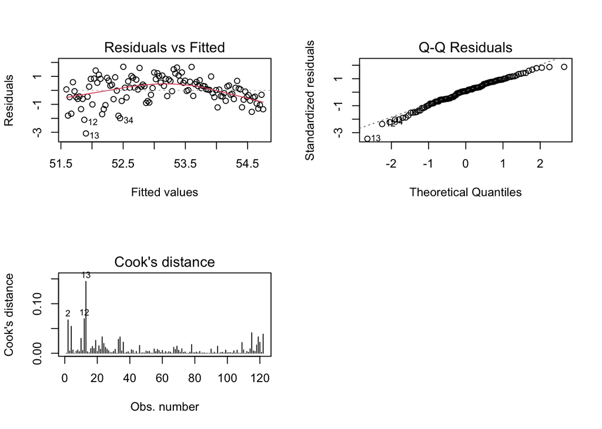

```r
par(mfrow=c(2,2)) #Tells R to display next 4 plots in 2x2 grid
plot(model1, which = c(1, 2, 4))
par(mfrow = c(1,1)) #Tells R to display plots in a "1x1" grid
```

## Example 3a - Building Models

```r
#Model1
model1recentered <- lm(speed ~ yearnew, data=derby)

#Model2
model2 <- lm(speed ~ fast, data = derby)

#Model3
model3 <- lm(speed ~ yearnew + fast, data = derby)

derby <-
  derby %>%
  mutate(yearnewFast = yearnew*fast)
#Model4
model4 <- lm(speed ~ yearnew + fast + yearnewFast, data = derby)
```

## Example 3b - Comparing Models 3 and 4

```r
#Compare summaries
summary(model3)
```

```
##
## Call:
## lm(formula = speed ~ yearnew + fast, data = derby)
##
## Residuals:
##      Min       1Q   Median       3Q      Max
## -2.36881 -0.43536  0.03596  0.45848  1.55688
##
## Coefficients:
##              Estimate Std. Error t value Pr(>|t|)
## (Intercept) 50.917822   0.154602  329.35  < 2e-16 ***
## yearnew      0.022583   0.001919   11.77  < 2e-16 ***
## fast         1.226846   0.150721    8.14 4.39e-13 ***
## ---
## Signif. codes:  0 '***' 0.001 '**' 0.01 '*' 0.05 '.' 0.1 ' ' 1
##
## Residual standard error: 0.7269 on 119 degrees of freedom
## Multiple R-squared:  0.6874, Adjusted R-squared:  0.6822
## F-statistic: 130.8 on 2 and 119 DF,  p-value: < 2.2e-16
```

```r
summary(model4)
```

```
##
## Call:
## lm(formula = speed ~ yearnew + fast + yearnewFast, data = derby)
##
## Residuals:
##      Min       1Q   Median       3Q      Max
## -2.41993 -0.38708  0.00816  0.43128  1.43478
##
## Coefficients:
##              Estimate Std. Error t value Pr(>|t|)
## (Intercept) 50.528629   0.205072 246.394  < 2e-16 ***
## yearnew      0.030751   0.003471   8.859 9.84e-15 ***
## fast         1.833523   0.262175   6.994 1.73e-10 ***
## yearnewFast -0.011490   0.004117  -2.791  0.00613 **
## ---
## Signif. codes:  0 '***' 0.001 '**' 0.01 '*' 0.05 '.' 0.1 ' ' 1
##
## Residual standard error: 0.7071 on 118 degrees of freedom
## Multiple R-squared:  0.7068, Adjusted R-squared:  0.6993
## F-statistic: 94.81 on 3 and 118 DF,  p-value: < 2.2e-16
```

```r
#Significance Test
anova(model3, model4)
```

```
## Analysis of Variance Table
##
## Model 1: speed ~ yearnew + fast
## Model 2: speed ~ yearnew + fast + yearnewFast
##   Res.Df    RSS Df Sum of Sq      F   Pr(>F)
## 1    119 62.886
## 2    118 58.991  1    3.8946 7.7904 0.006128 **
## ---
## Signif. codes:  0 '***' 0.001 '**' 0.01 '*' 0.05 '.' 0.1 ' ' 1
```

## Example 3c - Confidence Intervals for Model 3

```r
#Find Confidence Interval
confint(model3)
```

[output not shown]